# Assignment 4: Movie Review Analysis [50 Pt]

In this assignment, we will build a recurrent neural network to work with sequential text data, specificially, movie review data to identify the reviewer sentiment. In the process of completing this assignment, you will:

1. Clean and process text data for machine learning.
2. Perform tokenization of text data.
3. Understand and implement a word-level recurrent neural network.
4. Implement batching of text data using a DataLoader before training a recurrent neural network.
5. Understand how to apply pretrained models for transfer learning in natural language processing projects.

### What to submit

Submit an HTML file and an IPYNB file containing all your code, outputs, and write-up from parts A and B. You can produce a HTML file directly from Google Colab. The Colab instructions are provided at the end of this document.

Include a link to your colab file in your submission.

Please use Google Colab to complete this assignment. If you want to use Jupyter Notebook, please complete the assignment and upload your Jupyter Notebook file to Google Colab for submission.

## Colab Link

Include a link to your Colab file here. If you would like the TA to look at your Colab file in case your solutions are cut off, **please make sure that your Colab file is publicly accessible at the time of submission.**

```python
# TO BE COMPLETED

https://colab.research.google.com/drive/1eRx9TxNK6-m-lJGVyANgjs75yJ9ceN8k
```

# PART A - Sentiment Analysis

In this part we will construct a world-level LSTM model for identifying positive and negative reviews. This will be done in a similar way to what was shared in the preparation code for Assignment 4.

```python
# load standard modules/libraries
import pandas as pd
import numpy as np
import matplotlib.pyplot as plt
import seaborn as sns
from sklearn.model_selection import train_test_split

# load special modules/libraries
import os
import warnings
import nltk
from nltk.corpus import stopwords
nltk.download('stopwords')

from collections import Counter
import string
import re
from tqdm  import tqdm

# load pytorch modules/libraries
import torch
import torch.nn as nn
import torch.nn.functional as F
import torch.optim as optim
from torch.utils.data import TensorDataset,DataLoader
```

```python
DEVICE = torch.device("cuda" if torch.cuda.is_available() else "cpu")

CHECKPOINT_DIR = "checkpoints"
os.makedirs(CHECKPOINT_DIR, exist_ok=True)

def save_checkpoint(path, model, optimizer=None, epoch=None, best_val_acc=None, extra=None):
    checkpoint = {
        "model_state_dict": model.state_dict()
    }
    if optimizer is not None:
        checkpoint["optimizer_state_dict"] = optimizer.state_dict()
    if epoch is not None:
        checkpoint["epoch"] = epoch
    if best_val_acc is not None:
        checkpoint["best_val_acc"] = best_val_acc
    if extra is not None:
        checkpoint["extra"] = extra

    torch.save(checkpoint, path)

def load_checkpoint(path, model, optimizer=None, map_location=DEVICE):
    checkpoint = torch.load(path, map_location=map_location)
    model.load_state_dict(checkpoint["model_state_dict"])
    if optimizer is not None and "optimizer_state_dict" in checkpoint:
        optimizer.load_state_dict(checkpoint["optimizer_state_dict"])
    return checkpoint
```

## Part 1. Data Cleaning [5 pt]

We will be using the "IMDB Movie Review Dataset" provided on the course website. Download "IMDB Dataset.csv" into your Colab workspace.

### Part (i) [1pt EXPLORATORY]

Open up the file in Python, and examine some examples of positive and negative reviews. Comment on the quality of the data and any challenges you foresee in working with these data. Pick one example of a positive review and one of a negative review to support your comments.

```python
# download IMDB review data

# load dataset
df = pd.read_csv("IMDB Dataset.csv")

# process into data and labels
X = df['review'].values
y = df['sentiment'].values
```

```python
# TO BE COMPLETED

# Display multiple positive and negative reviews for better examination
num_examples = 3

#Postive review
print(f"Showing first {num_examples} Positive Reviews")
pos_reviews = df[df['sentiment'] == 'positive']['review'].head(num_examples)
for i, review in enumerate(pos_reviews, 1):
    print(f"\n[Positive Review #{i}]:")
    print(review[:500] + "..." if len(review) > 500 else review)

#Negative review
print(f"\nShowing first {num_examples} Negative Reviews")
neg_reviews = df[df['sentiment'] == 'negative']['review'].head(num_examples)
for i, review in enumerate(neg_reviews, 1):
    print(f"\n[Negative Review #{i}]:")
    print(review[:500] + "..." if len(review) > 500 else review)
```

```
Showing first 3 Positive Reviews

[Positive Review #1]:
I really liked this Summerslam due to the look of the arena, the curtains and just the look overall was interesting to me for some reason. Anyways, this could have been one of the best Summerslam's ever if the WWF didn't have Lex Luger in the main event against Yokozuna, now for it's time it was ok …

[Positive Review #2]:
Not many television shows appeal to quite as many different kinds of fans like Farscape does...I know youngsters and 30/40+ years old;fans both Male and Female in as many different countries as you can think of that just adore this T.V miniseries. It has elements that can be found in almost every ot…

[Positive Review #3]:
Jane Austen would definitely approve of this one!<br /><br />Gwyneth Paltrow does an awesome job capturing the attitude of Emma. She is funny without being excessively silly, yet elegant. She puts on a very convincing British accent (not being British myself, maybe I'm not the best judge, but she fo…

Showing first 3 Negative Reviews

[Negative Review #1]:
The film quickly gets to a major chase scene with ever increasing destruction. The first really bad thing is the guy hijacking Steven Seagal would have been beaten to pulp by Seagal's driving, but that probably would have ended the whole premise for the movie.<br /><br />It seems like they decided t…

[Negative Review #2]:
Expectations were somewhat high for me when I went to see this movie, after all I thought Steve Carell could do no wrong coming off of great movies like Anchorman, The 40 Year-Old Virgin, and Little Miss Sunshine. Boy, was I wrong.<br /><br />I'll start with what is right with this movie: at certain…

[Negative Review #3]:
I was very disappointed with this series. It had lots of cool graphics and that's about it. The level of detail it went into was minimal, and I always got the feeling the audience was being patronized -- there was a lot of what seemed to me as "This is extremely cool but we're not going to explain i…
```

```python
'''
PROVIDE YOUR ANSWER BELOW

The quality of the data is somewhat raw and noisy. Since the dataset consists of web-scraped reviews,
it contains leftover HTML tags (such as <br />), as seen in Positive Review 3 and Negative Review 1.

Furthermore, in Positive Review 3, the name 'Jane Austen' is capitalized. If not normalized to lowercase,
the model might treat these words differently than their lowercase counterparts.

Similarly, the word 'one!' poses a punctuation issue. Without cleaning, the tokenizer will treat 'one!' as a completely
distinct token from 'one'.

The main challenge will be text preprocessing and cleaning. If HTML tags are not properly removed, capitalizations are not
standardized, and punctuation is left intact, the tokenizer will treat all these variations as unique and meaningful words.
This would unnecessarily bloat the vocabulary, add noise, and negatively impact the performance of the sentiment analysis model.


'''
```

### Part (ii) [1pt EXPLORATORY]

Perform summary statistics on the dataset. What are the average, median, and 90th percentile word counts of a review? What are the word counts of the longest and shortest reviews?

How many positive reviews and negative reviews are there? Generate a histogram to compare the distribution of word counts for positive and negative reviews. Comment on any differences between the positive and negative reviews, including whether the review lengths appear skewed or contain outliers, and how that may affect the model you will be using later.

```
Word Count Stats
Average: 231.45
Median:  174.0
90th percentile: 451.0
Range: 6 to 2470 words

Class Distribution
sentiment
positive    20004
negative    19996
Name: count, dtype: int64
```

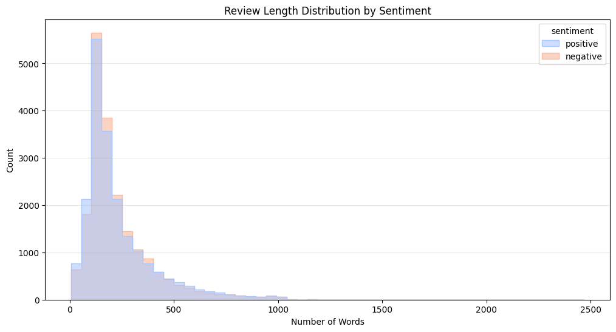

```python
# TO BE COMPLETED

# Calculate word counts per review
df['word_count'] = df['review'].apply(lambda x: len(x.split()))

# Quick summary
stats = df['word_count'].describe(percentiles=[.5, .9])
longest = df['word_count'].max()
shortest = df['word_count'].min()

print(f"Word Count Stats")
print(f"Average: {stats['mean']:.2f}")
print(f"Median:  {stats['50%']}")
print(f"90th percentile: {stats['90%']}")
print(f"Range: {shortest} to {longest} words")

# Class balance check
print(f"\nClass Distribution")
print(df['sentiment'].value_counts())

# Visualizing distributions
plt.figure(figsize=(12, 6))
sns.histplot(data=df, x='word_count', hue='sentiment', element='step', fill=True, palette='coolwarm', bins=50, alpha=0.6)
plt.title('Review Length Distribution by Sentiment')
plt.xlabel('Number of Words')
plt.ylabel('Count')
plt.grid(axis='y', alpha=0.3)
plt.show()
```

```python
'''

PROVIDE YOUR ANSWER BELOW

General observations :
The average word count is roughly 231 words, while the median is lower at 174 words.
The shortest review is 6 words, and the longest is 2,470 words.
We can see from the histragram, the distribution is heavily right-skewed.

Outliers:
The 90th percentile is 451 words; it means 90% of the reviews are shorter than 451 words.
However, the maximum length reaches up to 2,470 words, which indicates a long tail of very lengthy outlier reviews.


Observations positive vs negative:
The dataset is perfectly balanced with 20,004 positive reviews and 19,996 negative reviews.
From the histogram, the positive and negative reviews are almost the same, and overlapping with similar right-skewed tails.

Impact to the model:
The balanced class distribution can reduce the risk of bias toward one sentiment class during training.
However, the large variation in review length may affect text preprocessing and model design. The long-tail distribution
means that a small number of extremely long reviews could increase computational cost and may introduce noise.



'''
```